# RMarkDown Group B2 of RNAseq analysis with RStudio of:

Differential Expression Analysis of the transcriptome of human Trabecular meshwork cells stimulated with Transforming Growth Factor β-1 (TGF-β1) involved in Pseudoexfoliation Syndrome (XFS) and Glaucoma (XFG)

Gómez O.; Montalbán, SM.; Ostolaza, M. & Sánchez, M.

2nd Year in Biomedicine - Integrated Project IV - Year: 2024/25

#### NOTE: Libraries needed

- The following libraries are used for this analysis: `ggplot2`, `DESeq2` `edgeR`, `knitr`, `EnhancedVolcano`, `pheatmap`, `topGO`, `org.Hs.eg.db` and finally `wesanderson` for colouring the graphs.
- Most of them can be downloaded from CRAN repository, still, a file with how to download all the libraries can be found in this Github repository, the file is named: “Downloading_libraries_IP-IV”

## 1.PRE DATA PROCESSING AND GLOBAL UNDERSTANDING

### 1.1 Data Loading

- The data used in this analysis is obtained from: Genome-Wide RNA Sequencing of Human Trabecular Meshwork Cells Treated with TGF-β1: Relevance to Pseudoexfoliation Glaucoma study by Roodnat AW et.al.
  - *The article can be found in the following link https://pmc.ncbi.nlm.nih.gov/articles/PMC9687758/#biomolecules-12-01693-f005*
- For introducing the data (raw count matrix and metadata), it is necessary to set the working directory:

```r
setwd("/Users/marionaferrer/Downloads/galaxyB2 group")
```

- Loading the data obtained by galaxy (Feature counts annotated)

```r
SRR21709659 <- read.delim("/Users/marionaferrer/Downloads/galaxyB2 group/SRR21709659.tabular", row.names=1)
SRR21709660 <- read.delim("/Users/marionaferrer/Downloads/galaxyB2 group/SRR21709660.tabular", row.names=1)
SRR21709661 <- read.delim("/Users/marionaferrer/Downloads/galaxyB2 group/SRR21709661.tabular", row.names=1)
SRR21709662 <- read.delim("/Users/marionaferrer/Downloads/galaxyB2 group/SRR21709662.tabular", row.names=1)

SRR21709663 <- read.delim("/Users/marionaferrer/Downloads/galaxyB2 group/SRR21709663.tabular", row.names=1)
SRR21709664 <- read.delim("/Users/marionaferrer/Downloads/galaxyB2 group/SRR21709664.tabular", row.names=1)
SRR21709665 <- read.delim("/Users/marionaferrer/Downloads/galaxyB2 group/SRR21709665.tabular", row.names=1)
SRR21709666 <- read.delim("/Users/marionaferrer/Downloads/galaxyB2 group/SRR21709666.tabular", row.names=1)
```

- Joining the different table of counts:
  - C bind function can only be used when rows number are the same
  - It is important to check that all tables have the same number of rows (using nrows() function), since it is required for `cbind ()` function.

```r
counts_all <- cbind(SRR21709659, SRR21709660)
counts_all <- cbind(counts_all, SRR21709661)
counts_all <- cbind(counts_all, SRR21709662)
counts_all <- cbind(counts_all, SRR21709663)
counts_all <- cbind(counts_all, SRR21709664)
counts_all <- cbind(counts_all, SRR21709665)
counts_all <- cbind(counts_all, SRR21709666)
```

- Loading metadata

```r
metadata <- read.csv2("Metadata.csv", dec = ",", row.names = 1)
```

- In order to perform `DESeq2` metadata rows and column names need to be the same. Therefore it is required to check it:

```r
rownames(metadata) %in% colnames (counts_all)
```

```
## [1] TRUE TRUE TRUE TRUE TRUE TRUE TRUE TRUE
```

### 1.2 General Exploration

- In order to observe how the count matrix looks, the 25 first rows were explored.

```r
counts_all[1:25, ]
```

```
##           SRR21709659 SRR21709660 SRR21709661 SRR21709662 SRR21709663
## 100287102           4           0           0           4           0
## 653635            292         212         278         310         281
## 102466751          17           5          19           9          14
## 100302278           0           0           0           0           0
## 645520              0           0           0           0           0
## 79501               0           0           0           0           0
## 729737             40           0         158           0          36
## 102725121           2           1           2           1           0
## 102723897         307         181         321         223         192
## 102465909           0           1           1           0           0
## 729759              0           0           0           0           0
## 100132287           5           0           3           0           0
## 105378947           1           2           4           0           0
## 101928626           0           0           1           0           0
```

[output cut: 37 more lines]

- Another tool, for general exploration to determine how many rows and columns the count matrix has:

```r
dim(counts_all)
```

```
## [1] 28395     8
```

- Per condition (treatment and control) there are 4 individuals.

```r
table(metadata$Condition)
```

```
##
##   Control Treatment
##         4         4
```

### 1.3 Normalisation

- A general exploration of the library size was performed, to see whether there are any major discrepancies between the samples.
- RNAseq data is not normally distributed. Prior to differential gene expression analysis, the count matrix should be normalised.

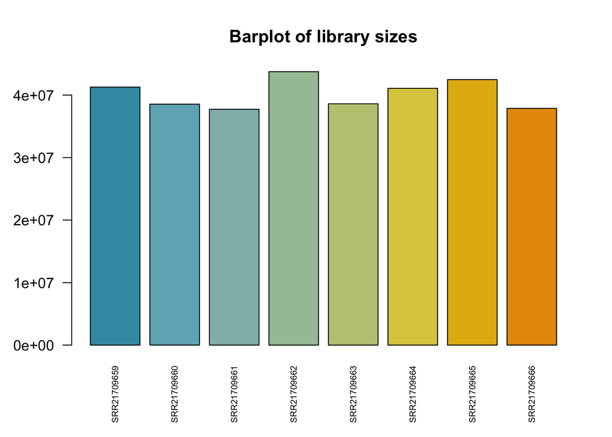

```r
barplot(colSums(counts_all),las=2, cex.names = 0.6,
        col=wes_palette(name="Zissou1", type = "continuous"),
        main ="Barplot of library sizes")
```

```r
#At first sight, no major discrepancies between samples can be observed.
#More or less all bars at the same level, meaning they have the same number of reads per each sample.
```

- Library size’s numbers:

```r
colSums(counts_all)
```

```
## SRR21709659 SRR21709660 SRR21709661 SRR21709662 SRR21709663 SRR21709664
##    41276142    38545797    37728759    43742706    38604400    41081139
## SRR21709665 SRR21709666
##    42469435    37868783
```

- Creation of a data frame only containing the numbers of the library size:

```r
df_library <- as.data.frame(colSums(counts_all))
# df_library --> for visualising the data frame that was created
```

- As mentioned RNAseq data is not normally distributed.
- Prior to differential gene expression analysis, the count matrix should be normalised. This can be done using the Computation of Counts Per Million Reads `(CPM)` function.
- Computation of Counts Per Million (CPMs) with the `edgeR` package:

```r
CPM <- cpm (counts_all)
# CPM[1:5, 1:5] --> to visualise the CPM data frame
```

### 1.4 Heatmap exploration

- Clustering/Heatmap
  - Clustering algorithms allow to group the observations and/or variables in our dataset, according to their similarity (dissimilarity).
  - The latter can be measured in many different ways (e.g. Euclidean distance, correlation, etc.).
  - Clustering is helpful to identify subgroups of individuals, outliers and batch effects.

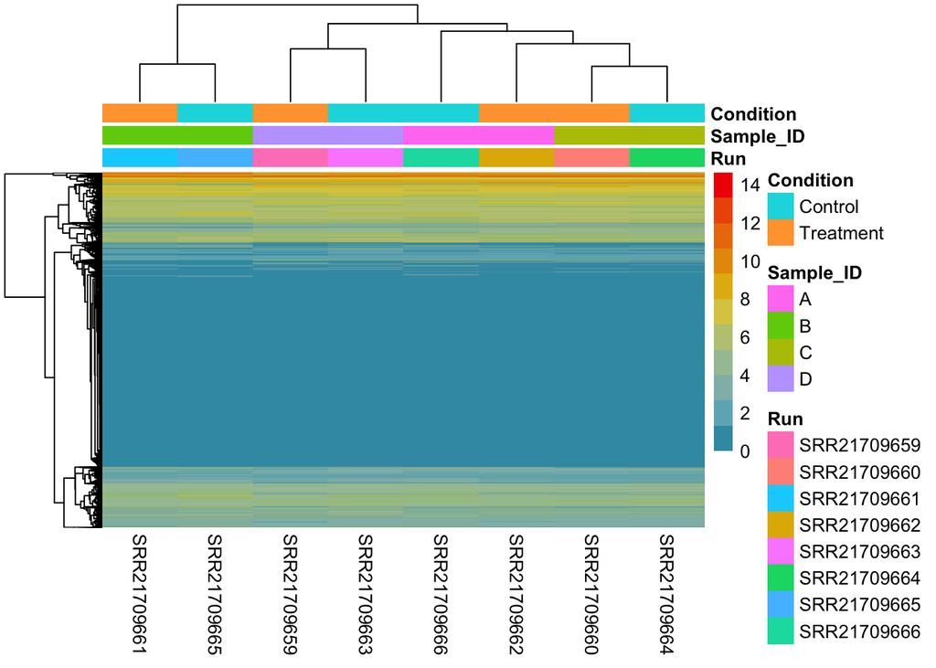

```r
pheatmap(log2(CPM + 1),
         show_rownames = F,
         annotation_col = metadata,
         col = wes_palette(name = "Zissou1", type = "continuous"))
```

### 1.5 DESeq2 object creation

- Again, as mentioned, the RNAseq data has no normal distribution therefore the application of parametric tests to compare expression of genes such as the T-test are not adequate.
- Using packages like `DESeq2` and `edgeR` a proper analysis including the normalisation of the data can be carried out.
- With `DESeq2` models, a negative binomial distribution is considered. There is no need to filter or check for any distribution.
- Creating a `DESeq2` object: combination of the counts and metadata information in a single object.
- **IMPORTANT:** It is advisable, to indicate the design of your analysis including the variables of interest.

```r
#For paired data, it is included here the id variable: design = Sample_ID + Condition
metadata$Sample_ID <- factor(metadata$Sample_ID)
dds <- DESeqDataSetFromMatrix(countData = counts_all,
                              colData = metadata,
                              design = ~ Sample_ID + Condition)
# Sample_ID was added since the data used is paired data.
# **Sex was not considered in the analysis because the algorithm fails to run since it detects associations within the data**

dds$Condition <- relevel(dds$Condition, ref = "Control") # To determine the reference
```

### 1.6 Principal Component Analysis (PCA) exploration

- Principal Component Analysis (PCA) is a technique used to emphasise variation and bring out strong patterns in a dataset (dimensionality reduction).
- Before plotting in a PCA it is necessary to normalise first. In this case rlog normalisation will be used.
- `Rlog` normalisation: this function transforms the count data to the log2 scale in a way which minimises differences between samples for rows with small counts, and which normalises with respect to library size (number of sequences obtained after sequencing).

```r
rsel <- rlog(dds, blind=TRUE)
```

- Obtention of the PCA plot:

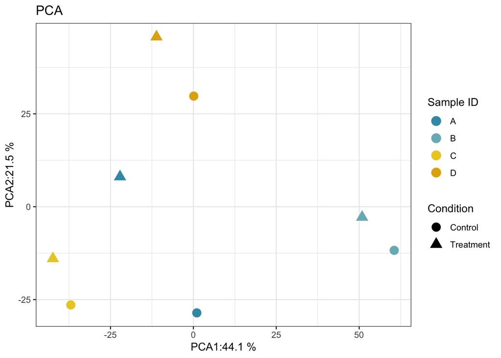

```r
pc <- prcomp(t(assay(rsel)))
pca <- as.data.frame(pc$x) # save as data frame
pca$SampleID <- rownames(metadata)
pca$Condition <- metadata$Condition
pca$Sample_ID <- metadata$Sample_ID
vars <- sprintf('%.1f %%',(pc$sdev)^2/sum(pc$sdev^2)*100)


PCA <- ggplot(pca, aes(PC1, PC2)) +
  geom_point(aes(colour = factor(Sample_ID), shape = factor(Condition)), size = 4) +
  scale_color_manual(values= c ("#3c9ab3", "#78b7c0", "#ebcc2a", "#e1af10")) +
  theme_bw() + labs(title = "PCA", y =paste0("PCA2:",vars[2]), x = paste0("PCA1:",vars[1]))+
  labs(tittle = "PCA", colour = "Sample ID", shape = "Condition")
PCA
```

## 2. DIFFERENTIAL EXPRESSION (DE) ANALYSIS WITH DESeq2

- Calculation of the differential expressed genes with `DESeq2` method:

```r
# Apply DESEeq2 method: this sample normalises the data and builts the statistical models to make the differential expression tests. The design was indicated in the 1.5 DESeq2 object creation section.
dds <- DESeq(dds)
# Save the results in a variable
res <- results(dds)
```

- Create a data frame with the results, in order to visualise them:

```r
df <- data.frame(results(dds))
# head(df) --> to visualise the data frame that presents 6 variables
```

- One of the variables from these results, is Adjusted p-values (padj).
  - The p-value stands for probability value; it indicates how likely it is that a result occurred by chance.
  - If the p-value is small, it indicates the results was unlikely to have occurred by chance alone. These results are knwon as being statistically significant.
- Another variable is the log2FoldChange.
  - The Fold change is a measure describing how much a quantity changes going from an initial to a final value or to one condition to another one.
- Finding valuable adjusted p-values (those who are less than 0.05, significant):

```r
res01 <- results(dds, alpha=0.05)
summary(res01) # 406 genes are up-regulated and 377 genes down-regulated
```

```
##
## out of 21436 with nonzero total read count
## adjusted p-value < 0.05
## LFC > 0 (up)       : 406, 1.9%
## LFC < 0 (down)     : 377, 1.8%
## outliers [1]       : 0, 0%
## low counts [2]     : 6536, 30%
## (mean count < 11)
## [1] see 'cooksCutoff' argument of ?results
## [2] see 'independentFiltering' argument of ?results
```

```r
#convert it as a dataframe:
res_sig <- as.data.frame(res01)
```

**IMPORTANT**: NA values correspond to filtered genes, that are lowly expressed in a few samples.

- With these data frame it is possible to affirm that 406 genes are up-regulated and 377 genes are down-regulated.
- The Log Fold Change (LFC) is used to assess gene regulation in response to the treatment.
  - A positive LFC indicates that genes are up-regulated in the treatment condition compared to the control, which serves as the reference (as mentioned in Section 1.5).
  - Conversely, a negative LFC signifies that genes are down-regulated under treatment conditions

### 2.1 Volcano plot exploration

- To observe the results from the differential expressed analysis, a Volcano plot was generated:

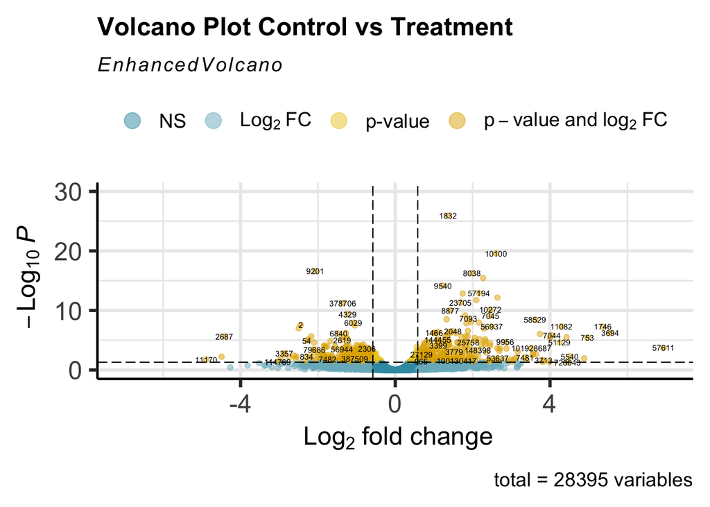

```r
EnhancedVolcano <- EnhancedVolcano(res, lab = rownames(res), x = 'log2FoldChange', y = 'padj',
                                            labSize = 2,  pointSize = 1.5, xlim = c(-7,7),ylim = c(0,30),FCcutoff = 0.58, pCutoff = 0.05, title = "Volcano Plot Control vs Treatment", col = wes_palette(n=4, name = "Zissou1"))

EnhancedVolcano
```

### 2.2 Heatmap exploration with DE genes

- With this input, a second heat map was performed considering **only** differential expressed genes.
- It is important to filter the genes that present a padj less than 0.05, indicating statistical significance, in order to reduce background noise:

```r
res_df <- as.data.frame(res)

# Filter by padj < 0.05
res_filtered <- res_df[which(res_df$padj < 0.05),]

# Sort by log2FoldChange in descending order
res_sorted <- res_filtered[order(res_filtered$log2FoldChange, decreasing = TRUE),]
# Select the first 3 genes that are up-regulated
top_3 <- res_sorted[1:3,]
top_3
```

```
##          baseMean log2FoldChange     lfcSE     stat       pvalue         padj
## 152816 5604.20683      11.553648 1.7847807 6.473427 9.580464e-11 5.074612e-08
## 57611    13.37177       6.932324 1.4429358 4.804319 1.552788e-06 1.896438e-04
## 3694     43.09188       5.555900 0.9217407 6.027618 1.663940e-09 6.073564e-07
```

```r
#indices <- rownames(top_3)
#indices
```

- Second heat map with **only** differential expressed genes:

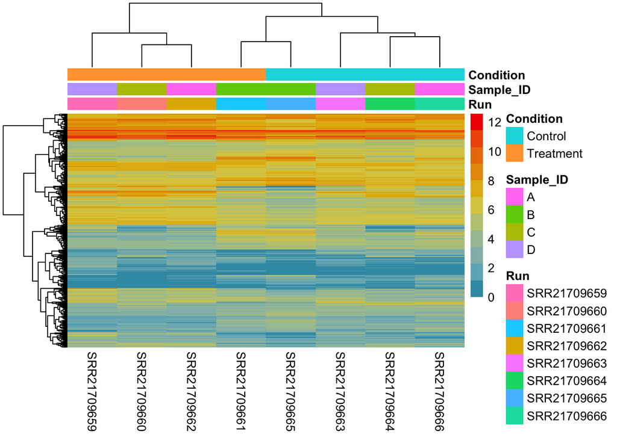

```r
data_counts <- log2(CPM + 1)
data_counts <- subset(data_counts, rownames(data_counts) %in% rownames(res_filtered))
pheatmap(data_counts,
         show_rownames = F,
         annotation_col = metadata,
         col = wes_palette(name = "Zissou1", type = "continuous"))
```

```r
# New clustering patterns are observed by the variable Condition, that is interesting since its different from prior heat map where the clustering pattern is according to Sample_ID variable.
```

## 3. GO ENRICHMENT

- To accomplish the aim of this article, Gene Ontology (GO) knowledgebase was used in order to define the functions.
- This tool is useful for determining whether any biological function is overrepresented among the differentially expressed genes in the dataset.
- GO knowledgebases is the world’s largest source of information on the functions of genes.
- A statistical test needs to be performed (e.g. hypergeometric test, Fisher test) for each function.
- Briefly, the test will determine if the number of genes associated to a pathway in the data set given to it is significantly larger than what would be expected by chance.
- Hence, for each function a P-value will be got, that it has to compare with the significance threshold (usually α = 0.05).
- In addition, it is necessary to correct for the fact of multiple testing functions (e.g. via False Discovery Rate).
- All these steps are performed using the `topGO` R package.

### 3.1 All Differentially Expressed genes

```r
# topGO requires all genes as a named list of P-values, plus a function to select significant genes (see below)
# in this case 'allGenes' or the 'universe' of genes are all the genes that have been tested in the DE analysis

#Create a res table without the NAs:
res_ok <- na.omit(res)
allGenes <- res_ok$padj # filtered by adjusted p-value
names(allGenes) <- rownames(res_ok)

# Create topGO object
GOdata <- new("topGOdata",
              ontology = "BP",                 # 'Biological Process' domain of GO
              allGenes = allGenes,             # The 'universe' of genes
              geneSel = function(p){p < 0.05}, # Define function (selects genes with adjusted P-values below 0.05)
              annotationFun = annFUN.org,      # Function to map gene IDs to GO terms
              mapping = "org.Hs.eg.db",        # H. sapiens annotation
              ID = "entrez")                   # The identifier used for the genes, "entrez gene IDs"
```

```
##
## Building most specific GOs .....
```

```
##  ( 11079 GO terms found. )
```

```
##
## Build GO DAG topology ..........
```

```
##  ( 14366 GO terms and 31871 relations. )
```

```
##
## Annotating nodes ...............
```

```
##  ( 12517 genes annotated to the GO terms. )
```

```r
# Run Fisher test
resultFisher <- runTest(GOdata, algorithm = "classic", statistic = "fisher")
```

```
##
##           -- Classic Algorithm --
##
##       the algorithm is scoring 6582 nontrivial nodes
##       parameters:
##           test statistic: fisher
```

```r
# Results (top 100)
GOres <- GenTable(GOdata, classicFisher = resultFisher, topNodes = 100)
```

- For visualising the top 6 biological processes:

```r
head(GOres)
```

```
##        GO.ID                               Term Annotated Significant Expected
## 1 GO:0032501   multicellular organismal process      4829         390   275.07
## 2 GO:0048856   anatomical structure development      4306         357   245.28
## 3 GO:0048731                 system development      3016         272   171.80
## 4 GO:0007275 multicellular organism development      3508         300   199.82
## 5 GO:0009888                 tissue development      1425         156    81.17
## 6 GO:0032502              developmental process      4683         370   266.76
##   classicFisher
## 1       2.1e-19
## 2       5.9e-19
## 3       5.2e-18
## 4       7.9e-17
## 5       1.0e-16
## 6       4.0e-16
```

#### 3.1.1 ID obtention of significant genes in each of the GO.ID from the data of interest

```r
#1) List of all the genes annotated to each term
gogenes_DE <- genesInTerm(GOdata)

#2) Significant Genes
sigGenes_DE <- sigGenes(GOdata)


#3) Naming specific geneterms
GOterm_1DE <-"GO:0032501"
GOterm_2DE <-"GO:0048856"
GOterm_3DE <-"GO:0048731"
GOterm_4DE <-"GO:0007275"
GOterm_5DE <-"GO:0009888"

#4) Annotating genes in each go term
allGenesInTerm_1DE<-gogenes_DE[[GOterm_1DE]]
allGenesInTerm_2DE<-gogenes_DE[[GOterm_2DE]]
allGenesInTerm_3DE<-gogenes_DE[[GOterm_3DE]]
allGenesInTerm_4DE<-gogenes_DE[[GOterm_4DE]]
allGenesInTerm_5DE<-gogenes_DE[[GOterm_5DE]]

#5) Intersection to obtain significant genes within the article data
sigGenesInTerm_1DE<-intersect(allGenesInTerm_1DE, sigGenes_DE)
#sigGenesInTerm_1DE  #The top 3 significant genes can be found in this GO term: "152816", "57611"  and "3694"

sigGenesInTerm_2DE<-intersect(allGenesInTerm_2DE, sigGenes_DE)
#sigGenesInTerm_2DE  #The top 3 significant genes can be found in this GO term: "152816", "57611"  and "3694"

sigGenesInTerm_3DE<-intersect(allGenesInTerm_3DE, sigGenes_DE)
#sigGenesInTerm_3DE #Only 2 out of the 3 top genes can be found in this GO term: "57611" and  "3694"

sigGenesInTerm_4DE<-intersect(allGenesInTerm_4DE, sigGenes_DE)
#sigGenesInTerm_4DE #The top 3 significant genes can be found in this GO term: "152816", "57611"  and "3694"

sigGenesInTerm_5DE<-intersect(allGenesInTerm_5DE, sigGenes_DE)
#sigGenesInTerm_5DE #Only 2 out of the 3 top genes can be found in this GO term: "152816" and  "3694"
```

### 3.2 Differentially expressed genes and Up-regulated

#### 3.2.1 Differentially expressed genes and Up-regulated: log2 foldchange > 1

```r
res_ok_up1 <- subset(res_ok, res_ok$log2FoldChange > 1) # filtered by logFold > 1
allGenesup1 <- res_ok_up1$padj
names(allGenesup1) <- rownames(res_ok_up1)

# Create topGO object
GOdata_up1 <- new("topGOdata",
              ontology = "BP",                 # The 'Biological Process' domain of GO is the focus of this analysis
              allGenes = allGenesup1,             # The 'universe' of genes
              geneSel = function(p){p < 0.05}, # Define function (selects genes with adjusted P-values below 0.05)
              annotationFun = annFUN.org,      # Function to map gene IDs to GO terms
              mapping = "org.Hs.eg.db",        # H. sapiens annotation
              ID = "entrez")                   # The identifier used for the genes, "entrez gene IDs"
```

```
##
## Building most specific GOs .....
```

```
##  ( 2382 GO terms found. )
```

```
##
## Build GO DAG topology ..........
```

```
##  ( 5348 GO terms and 11568 relations. )
```

```
##
## Annotating nodes ...............
```

```
##  ( 430 genes annotated to the GO terms. )
```

```r
# Run Fisher test
resultFisher <- runTest(GOdata_up1, algorithm = "classic", statistic = "fisher")
```

```
##
##           -- Classic Algorithm --
##
##       the algorithm is scoring 3481 nontrivial nodes
##       parameters:
##           test statistic: fisher
```

```r
# Results (top 100)
GOres_up1 <- GenTable(GOdata_up1, classicFisher = resultFisher, topNodes = 100)
```

- Visualising the top 6 biological processes

```r
head(GOres_up1)
```

```
##        GO.ID                                        Term Annotated Significant
## 1 GO:1901137 carbohydrate derivative biosynthetic pro...        15          13
## 2 GO:0007275          multicellular organism development       209         107
## 3 GO:0032501            multicellular organismal process       276         135
## 4 GO:0001503                                ossification        33          23
## 5 GO:0048513                    animal organ development       146          78
## 6 GO:0090101 negative regulation of transmembrane rec...        13          11
##   Expected classicFisher
## 1     6.49       0.00058
## 2    90.40       0.00085
## 3   119.39       0.00101
## 4    14.27       0.00133
## 5    63.15       0.00162
## 6     5.62       0.00248
```

- The team has chosen to carry out a more in restrictive filter since the GO.ID found are not strongly linked to XFS/XFG.

#### 3.2.2 Differentially expressed genes and Up-regulated: log2 foldchange > 2

```r
res_ok_up2 <- subset(res_ok, res_ok$log2FoldChange > 2) # filtered by logFold > 2
allGenesup2 <- res_ok_up2$padj
names(allGenesup2) <- rownames(res_ok_up2)

# Create topGO object
GOdata_up2 <- new("topGOdata",
              ontology = "BP",                 # The 'Biological Process' domain of GO is the focus of this analysis
              allGenes = allGenesup2,             # The 'universe' of genes
              geneSel = function(p){p < 0.05}, # Define function (selects genes with adjusted P-values below 0.05)
              annotationFun = annFUN.org,      # Function to map gene IDs to GO terms
              mapping = "org.Hs.eg.db",        # H. sapiens annotation
              ID = "entrez")                   # The identifier used for the genes, "entrez gene IDs"
```

```
##
## Building most specific GOs .....
```

```
##  ( 819 GO terms found. )
```

```
##
## Build GO DAG topology ..........
```

```
##  ( 2613 GO terms and 5476 relations. )
```

```
##
## Annotating nodes ...............
```

```
##  ( 106 genes annotated to the GO terms. )
```

```r
# Run Fisher test
resultFisher <- runTest(GOdata_up2, algorithm = "classic", statistic = "fisher")
```

```
##
##           -- Classic Algorithm --
##
##       the algorithm is scoring 1510 nontrivial nodes
##       parameters:
##           test statistic: fisher
```

```r
# Results (top 100)
GOres_up2 <- GenTable(GOdata_up2, classicFisher = resultFisher, topNodes = 100)
```

- Visualising the top 6 biological processes

```r
head(GOres_up2)
```

```
##        GO.ID                                        Term Annotated Significant
## 1 GO:0007178 cell surface receptor protein serine/thr...         7           7
## 2 GO:0141091 transforming growth factor beta receptor...         7           7
## 3 GO:0090092 regulation of transmembrane receptor pro...         6           6
## 4 GO:0006022               aminoglycan metabolic process         5           5
## 5 GO:0007179 transforming growth factor beta receptor...         5           5
## 6 GO:0030203         glycosaminoglycan metabolic process         5           5
##   Expected classicFisher
## 1     4.03         0.018
## 2     4.03         0.018
## 3     3.45         0.033
## 4     2.88         0.059
## 5     2.88         0.059
## 6     2.88         0.059
```

##### 3.2.2.1 ID obtention of significant genes in each of the GO.ID from the data of interest

```r
#1) List of all the genes annotated to each term
gogenes_up2 <- genesInTerm(GOdata_up2)

#2) Significant Genes
sigGenes_up2 <- sigGenes(GOdata_up2)


#3) Naming specific geneterms
GOterm_1up2<-"GO:0007178"
GOterm_2up2<-"GO:0141091"
GOterm_3up2<-"GO:0090092"
GOterm_4up2<-"GO:0006022"
GOterm_5up2<-"GO:0007179"

#4) Annotating genes in each go term
allGenesInTerm_1up2<-gogenes_up2[[GOterm_1up2]]
allGenesInTerm_2up2<-gogenes_up2[[GOterm_2up2]]
allGenesInTerm_3up2<-gogenes_up2[[GOterm_3up2]]
allGenesInTerm_4up2<-gogenes_up2[[GOterm_4up2]]
allGenesInTerm_5up2<-gogenes_up2[[GOterm_5up2]]

#5) Intersection to obtain signficnt genes within the article data
sigGenesInTerm_1up2<-intersect(allGenesInTerm_1up2, sigGenes_up2)
#sigGenesInTerm_1up2 #Only 1 out of the 3 top genes can be found in this GO term: "3694"

sigGenesInTerm_2up2<-intersect(allGenesInTerm_2up2, sigGenes_up2)
#sigGenesInTerm_2up2 #Only 1 out of the 3 top genes can be found in this GO term: "3694"

sigGenesInTerm_3up2<-intersect(allGenesInTerm_3up2, sigGenes_up2)
#sigGenesInTerm_3up2 #Any of the 3 top genes can be found in this GO term

sigGenesInTerm_4up2<-intersect(allGenesInTerm_4up2, sigGenes_up2)
#sigGenesInTerm_4up2  #Any of the 3 top genes can be found in this GO term

sigGenesInTerm_5up2<-intersect(allGenesInTerm_5up2, sigGenes_up2)
#sigGenesInTerm_5up2 #Only 1 out of the 3 top genes can be found in this GO term: "3694"
```

### 3.3 Differentially expressed genes and Down-regulated

#### 3.3.1 Differentially expressed genes and Down-regulated: log2 foldchange < -1

```r
res_ok_down1 <- subset(res_ok, res_ok$log2FoldChange < -1)# filtered by logFold < -1
allGenesdown1 <- res_ok_down1$padj
names(allGenesdown1) <- rownames(res_ok_down1)

# Create topGO object
GOdata_down1 <- new("topGOdata",
              ontology = "BP",                 # The 'Biological Process' domain of GO is the focus of this analysis
              allGenes = allGenesdown1,             # The 'universe' of genes
              geneSel = function(p){p < 0.05}, # Define function (selects genes with adjusted P-values below 0.05)
              annotationFun = annFUN.org,      # Function to map gene IDs to GO terms
              mapping = "org.Hs.eg.db",        # H. sapiens annotation
              ID = "entrez")                   # The identifier used for the genes, "entrez gene IDs"
```

```
##
## Building most specific GOs .....
```

```
##  ( 2292 GO terms found. )
```

```
##
## Build GO DAG topology ..........
```

```
##  ( 5248 GO terms and 11338 relations. )
```

```
##
## Annotating nodes ...............
```

```
##  ( 385 genes annotated to the GO terms. )
```

```r
# Run Fisher test
resultFisher <- runTest(GOdata_down1, algorithm = "classic", statistic = "fisher")
```

```
##
##           -- Classic Algorithm --
##
##       the algorithm is scoring 3519 nontrivial nodes
##       parameters:
##           test statistic: fisher
```

```r
# Results (top 100)
GOres_down1 <- GenTable(GOdata_down1, classicFisher = resultFisher, topNodes = 100)
```

- Visualising the top 6 biological processes

```r
head(GOres_down1)
```

```
##        GO.ID                                Term Annotated Significant Expected
## 1 GO:0008104                protein localization        51          31    20.00
## 2 GO:0070727 cellular macromolecule localization        51          31    20.00
## 3 GO:0033036          macromolecule localization        67          37    26.28
## 4 GO:0032880  regulation of protein localization        23          15     9.02
## 5 GO:0014823                response to activity         5           5     1.96
## 6 GO:0034504     protein localization to nucleus         5           5     1.96
##   classicFisher
## 1        0.0007
## 2        0.0007
## 3        0.0027
## 4        0.0086
## 5        0.0089
## 6        0.0089
```

- The team has chosen to carry out a more restrictive filter since the GO.ID found are not strongly linked to the XFS/XFG.

#### 3.3.2 Differentially expressed genes and Down-regulated: log2 foldchange < -2

```r
res_ok_down2 <- subset(res_ok, res_ok$log2FoldChange < -2)
allGenesdown2 <- res_ok_down2$padj
names(allGenesdown2) <- rownames(res_ok_down2)

# Create topGO object
GOdata_down2 <- new("topGOdata",
              ontology = "BP",                 # The 'Biological Process' domain of GO is the focus of this analysis
              allGenes = allGenesdown2,             # The 'universe' of genes
              geneSel = function(p){p < 0.05}, # Define function (selects genes with adjusted P-values below 0.05)
              annotationFun = annFUN.org,      # Function to map gene IDs to GO terms
              mapping = "org.Hs.eg.db",        # H. sapiens annotation
              ID = "entrez")                   # The identifier used for the genes, "entrez gene IDs"
```

```
##
## Building most specific GOs .....
```

```
##  ( 559 GO terms found. )
```

```
##
## Build GO DAG topology ..........
```

```
##  ( 2014 GO terms and 4242 relations. )
```

```
##
## Annotating nodes ...............
```

```
##  ( 58 genes annotated to the GO terms. )
```

```r
# Run Fisher test
resultFisher <- runTest(GOdata_down2, algorithm = "classic", statistic = "fisher")
```

```
##
##           -- Classic Algorithm --
##
##       the algorithm is scoring 1298 nontrivial nodes
##       parameters:
##           test statistic: fisher
```

```r
# Results (top 100)
GOres_down2 <- GenTable(GOdata_down2, classicFisher = resultFisher, topNodes = 100)
```

- Visualising the top 6 biological processes

```r
head(GOres_down2)
```

```
##        GO.ID                                        Term Annotated Significant
## 1 GO:0002831 regulation of response to biotic stimulu...         4           4
## 2 GO:0043933     protein-containing complex organization         6           5
## 3 GO:0065003         protein-containing complex assembly         6           5
## 4 GO:0097435           supramolecular fiber organization         6           5
## 5 GO:0007015                 actin filament organization         3           3
## 6 GO:0008154    actin polymerization or depolymerization         3           3
##   Expected classicFisher
## 1     1.59         0.021
## 2     2.38         0.032
## 3     2.38         0.032
## 4     2.38         0.032
## 5     1.19         0.057
## 6     1.19         0.057
```

##### 3.3.2.1 ID obtention of significant genes in each of the GO.ID from the data of interest

```r
#1) List of all the genes annotated to each term
gogenes_down2 <- genesInTerm(GOdata_down2)

#2) Significant Genes
sigGenes_down2 <- sigGenes(GOdata_down2)

#3) Naming specific geneterms
GOterm_1down2<-"GO:0002831"
GOterm_2down2<-"GO:0043933"
GOterm_3down2<-"GO:0065003"
GOterm_4down2<-"GO:0097435"
GOterm_5down2<-"GO:0097435"

#4) Anotaiting genes in each go term
allGenesInTerm_1down2<-gogenes_down2[[GOterm_1down2]]
allGenesInTerm_2down2<-gogenes_down2[[GOterm_2down2]]
allGenesInTerm_3down2<-gogenes_down2[[GOterm_3down2]]
allGenesInTerm_4down2<-gogenes_down2[[GOterm_4down2]]
allGenesInTerm_5down2<-gogenes_down2[[GOterm_5down2]]

#5) Intersectioon to obtain signficnt genes within the article data
sigGenesInTerm_1down2<-intersect(allGenesInTerm_1down2, sigGenes_down2)
#sigGenesInTerm_1down2  #Any of the 3 top genes can be found in this GO term

sigGenesInTerm_2down2<-intersect(allGenesInTerm_2down2, sigGenes_down2)
#sigGenesInTerm_2down2  #Any of the 3 top genes can be found in this GO term

sigGenesInTerm_3down2<-intersect(allGenesInTerm_3down2, sigGenes_down2)
#sigGenesInTerm_3down2  #Any of the 3 top genes can be found in this GO term

sigGenesInTerm_4down2<-intersect(allGenesInTerm_4down2, sigGenes_down2)
#sigGenesInTerm_4down2  #Any of the 3 top genes can be found in this GO term

sigGenesInTerm_5down2<-intersect(allGenesInTerm_5down2, sigGenes_down2)
#sigGenesInTerm_5down2  #Any of the 3 top genes can be found in this GO term
```

## 4. SAVE THE ANALYSIS

- In order to save all the objects (Tables, variables, etc) from the current environment:

```r
# To save
save.image(file = "github_prova2.RData")


# To load the data next time the document is opened
#load(("/Users/sanumaya/Downloads/B2 group"/"RNA-seq analysis with R.RData"))

load("/Users/marionaferrer/Downloads/galaxyB2 group/github_prova2.RData")
```

- To ensure the reproducibility of this analysis, the packages used, their corresponding versions, and the R version are displayed using the `sessionInfo()` function.
- Additionally, this information can be saved as follows:

[session information not shown]

```r
# To save
# sinf <- sessionInfo()
```